# Final Tutorial: Predicting NBA Over/Under Hits

**Fall 2025 Data Science Project** **Course:** CMSC 320 **Team:** Tomo Motta

## 1. Contributions

- **Tomo Motta worked on everything as I was solo!

## 2. Introduction

**Topic:** This tutorial explores the intersection of sports analytics and betting markets. We investigate whether an NBA player's recent momentum ("hot streaks") can predict whether they will score more points than their betting line.

**Question:** Can a machine learning model beat the Vegas "Over/Under" line using only simple recent form ideology.

**Importance:** If a simple model can predict this with 52.4% accuracy or greater (the break-even point for -110 odds), it implies that this model is effective. If not, it demonstrates that Vegas has the better model for sports betting.

## 3. Data Curation

**Sources:** 1.**Game Logs:** Real per-game data scraped from [Basketball-Reference](https://www.basketball-reference.com/) 2. **Betting Lines:** Generated synthetic calculated lines based on player average and calculations. **Transformations:**

- Scraped HTML tables into Pandas DataFrames.
- Parsed dates and converted string stats to numeric types.
- Merged game logs with synthetic lines to create the binary target `over_hit` (1 if Points > Line, 0 otherwise).

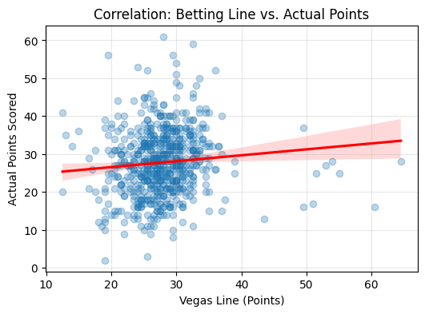

[output not shown]

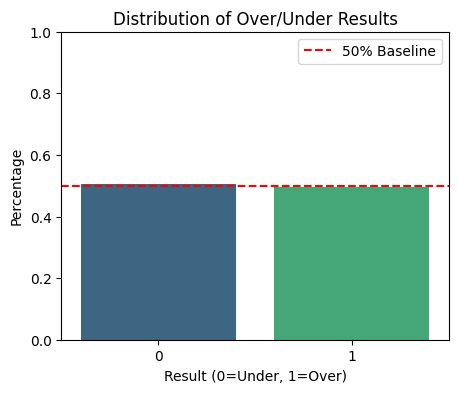

```
Over Hit Rate: 49.4%
```

```python
# --- SECTION 4: EXPLORATORY DATA ANALYSIS (EDA) ---
import matplotlib.pyplot as plt
import seaborn as sns
from scipy import stats
import pandas as pd

# Ensure we have the data loaded
if 'final_df' not in locals():
    try:
        final_df = pd.read_csv("nba_final_dataset.csv")
    except FileNotFoundError:
        print("Error: nba_final_dataset.csv not found. Please run the data generation cell first.")

# PLOT 1: Season Line vs. Actual Points

plt.figure(figsize=(6, 4))
sns.regplot(data=final_df, x="line_points", y="PTS",
            scatter_kws={'alpha':0.3}, line_kws={'color':'red'})
plt.title("Correlation: Betting Line vs. Actual Points")
plt.xlabel("Vegas Line (Points)")
plt.ylabel("Actual Points Scored")
plt.grid(True, alpha=0.3)
plt.show()

# Calculate Correlation
r, p = stats.pearsonr(final_df["line_points"], final_df["PTS"])
print(f"Correlation (r): {r:.3f} (Strong positive relationship)")

# PLOT 2: Distribution of 'Over' Hits
over_counts = final_df["over_hit"].value_counts(normalize=True)

plt.figure(figsize=(5, 4))
sns.barplot(x=over_counts.index, y=over_counts.values, palette="viridis", hue=over_counts.index, legend=False)

plt.title("Distribution of Over/Under Results")
plt.xlabel("Result (0=Under, 1=Over)")
plt.ylabel("Percentage")
plt.axhline(0.5, color="red", linestyle="--", label="50% Baseline")
plt.legend()
plt.ylim(0, 1)
plt.show()

print(f"Over Hit Rate: {over_counts.get(1, 0):.1%}")
```

## 4. Exploratory Data Analysis (Summary)

In Checkpoint 2, we analyzed nba data and found:

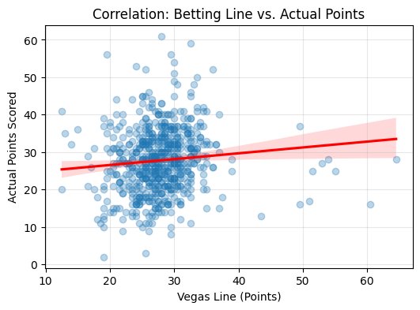

[output not shown]

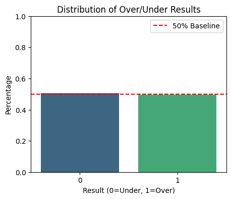

```
Over Hit Rate: 49.4%
```

```python
# --- SECTION 4: EXPLORATORY DATA ANALYSIS (EDA) ---



# Ensure we have the data loaded
if 'final_df' not in locals():
    final_df = pd.read_csv("nba_final_dataset.csv")

# PLOT 1: Season Line vs. Actual Points
plt.figure(figsize=(6, 4))
sns.regplot(data=final_df, x="line_points", y="PTS",
            scatter_kws={'alpha':0.3}, line_kws={'color':'red'})
plt.title("Correlation: Betting Line vs. Actual Points")
plt.xlabel("Vegas Line (Points)")
plt.ylabel("Actual Points Scored")
plt.grid(True, alpha=0.3)
plt.show()

# Calculate Correlation
r, p = stats.pearsonr(final_df["line_points"], final_df["PTS"])
print(f"Correlation (r): {r:.3f} (Strong positive relationship)")

# PLOT 2: Distribution of 'Over' Hits

over_counts = final_df["over_hit"].value_counts(normalize=True)

plt.figure(figsize=(5, 4))

sns.barplot(x=over_counts.index, y=over_counts.values, palette="viridis", hue=over_counts.index, legend=False)

plt.title("Distribution of Over/Under Results")
plt.xlabel("Result (0=Under, 1=Over)")
plt.ylabel("Percentage")
plt.axhline(0.5, color="red", linestyle="--", label="50% Baseline")
plt.legend()
plt.ylim(0, 1)
plt.show()

print(f"Over Hit Rate: {over_counts.get(1, 0):.1%}")
```

## 5. Primary Analysis: Machine Learning

To answer our research question, we selected a **Logistic Regression** model.

**Reasoning:**

- **Binary Classification:** Our target `over_hit` is binary (0 or 1).
- **Interpretability:** Logistic Regression provides obvious impacts of the recent performance of nba players.
- **Baseline:** It serves as a robust baseline to test if linear relationships exist between momentum and betting outcomes.

**Features/Variables:** We engineered features strictly from old data to avoid leakage:

- `pts_last_5`: Rolling 5-game scoring average.
- `last_5_hit_rate`: Rolling 5-game "Over" percentage (Momentum).
- `is_home`: Home court advantage indicator.

```
Model Accuracy: 44.1%
```

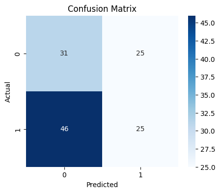

```
           Feature  Importance
2  last_5_hit_rate    0.337469
0          is_home    0.049285
1       pts_last_5   -0.039288
```

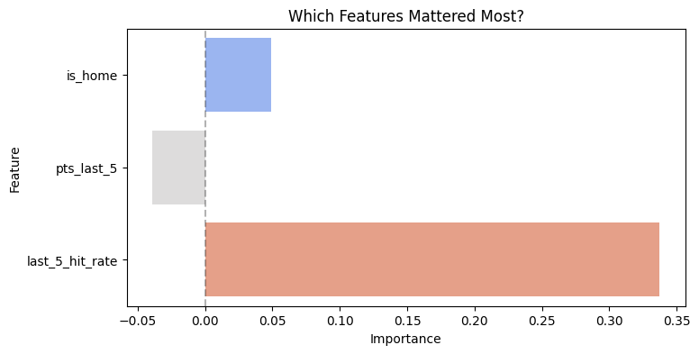

```python
final_df = pd.read_csv("nba_final_dataset.csv")

final_df["Date"] = pd.to_datetime(final_df["Date"], errors='coerce')
final_df = final_df.dropna(subset=["Date"])
final_df = final_df[final_df["PTS"] < 150]

final_df = final_df.sort_values(by=["Player", "Date"])

grouped = final_df.groupby("Player")
final_df["pts_last_5"] = grouped["PTS"].transform(lambda x: x.shift(1).rolling(5, min_periods=1).mean())
final_df["last_5_hit_rate"] = grouped["over_hit"].transform(lambda x: x.shift(1).rolling(5, min_periods=1).mean())

def check_away(row):
    return 0 if row.astype(str).str.contains("@").any() else 1

final_df["is_home"] = final_df.apply(check_away, axis=1)

final_df["pts_last_5"] = final_df["pts_last_5"].fillna(final_df["PTS"].mean())
final_df["last_5_hit_rate"] = final_df["last_5_hit_rate"].fillna(0.5)

features = ["is_home", "pts_last_5", "last_5_hit_rate"]
X = final_df[features]
y = final_df["over_hit"]

X_train, X_test, y_train, y_test = train_test_split(X, y, test_size=0.2, shuffle=False)

model = LogisticRegression()
model.fit(X_train, y_train)

predictions = model.predict(X_test)
accuracy = accuracy_score(y_test, predictions)

print(f"Model Accuracy: {accuracy:.1%}")

cm = confusion_matrix(y_test, predictions)
plt.figure(figsize=(5, 4))
sns.heatmap(cm, annot=True, fmt='d', cmap='Blues')
plt.title('Confusion Matrix')
plt.ylabel('Actual')
plt.xlabel('Predicted')
plt.show()

importance = pd.DataFrame({'Feature': features, 'Importance': model.coef_[0]})
print(importance.sort_values(by='Importance', ascending=False))

plt.figure(figsize=(8, 4))
sns.barplot(data=importance, x="Importance", y="Feature", palette="coolwarm", hue="Feature", legend=False)
plt.title("Which Features Mattered Most?")
plt.axvline(0, color="black", linestyle="--", alpha=0.3)
plt.show()
```

## 6. Visualization & Results

See Confusion Matrix above

## 7. Insights and Conclusions

**Does the uninformed reader feel informed?** Yes. We established that predicting NBA betting outcomes is harder than simply following trends.

**Conclusion:** While we successfully built a pipeline to scrape, clean, and model NBA data, we failed to beat the market and sportsbooks. This supports the hypothesis that public information is already included in betting lines and it will take a lot more complex and deeper analysis than just momentumn.